# Running Multiple Chains (Sequentially or in Parallel) in StochTree

Mixing of an MCMC sampler is a perennial concern for complex Bayesian models. BART and BCF are no exception. On common way to address such concerns is to run multiple independent "chains" of an MCMC sampler, so that if each chain gets stuck in a different region of the posterior, their combined samples attain better coverage of the full posterior.

This idea works with the classic "root-initialized" MCMC sampler of Chipman et al (2010), but a key insight of He and Hahn (2023) and Krantsevich et al (2023) is that the GFR algorithm may be used to warm-start initialize multiple chains of the BART / BCF MCMC sampler.

Operationally, the above two approaches have the same implementation (setting `num_gfr > 0` if warm-start initialization is desired), so this vignette will demonstrate how to run a multi-chain sampler sequentially.

To begin, load `stochtree` and other relevant libraries

```python
import numpy as np
import matplotlib.pyplot as plt
import arviz as az
from sklearn.model_selection import train_test_split
from stochtree import BARTModel, BCFModel
```

import numpy as np import matplotlib.pyplot as plt import arviz as az from sklearn.model_selection import train_test_split from stochtree import BARTModel, BCFModel

# Demo 1: Supervised Learning

## Data Simulation

Simulate a simple partitioned linear model

```python
# Generate the data
random_seed = 1111
rng = np.random.default_rng(random_seed)
n = 500
p_x = 10
p_w = 1
snr = 3
X = rng.uniform(size=(n, p_x))
leaf_basis = rng.uniform(size=(n, p_w))
f_XW = (((0 <= X[:, 0]) & (0.25 > X[:, 0])) *
         (-7.5 * leaf_basis[:, 0]) +
         ((0.25 <= X[:, 0]) & (0.5 > X[:, 0])) * (-2.5 * leaf_basis[:, 0]) +
         ((0.5 <= X[:, 0]) & (0.75 > X[:, 0])) * (2.5 * leaf_basis[:, 0]) +
         ((0.75 <= X[:, 0]) & (1 > X[:, 0])) * (7.5 * leaf_basis[:, 0]))
noise_sd = np.std(f_XW) / snr
y = f_XW + rng.normal(0, noise_sd, size=n)

# Split data into test and train sets
test_set_pct = 0.2
train_inds, test_inds = train_test_split(np.arange(n), test_size=test_set_pct, random_state=random_seed)
n_train = len(train_inds)
n_test = len(test_inds)
X_train = X[train_inds]
X_test = X[test_inds]
leaf_basis_train = leaf_basis[train_inds]
leaf_basis_test = leaf_basis[test_inds]
y_train = y[train_inds]
y_test = y[test_inds]
```

# Generate the data random_seed = 1111 rng = np.random.default_rng(random_seed) n = 500 p_x = 10 p_w = 1 snr = 3 X = rng.uniform(size=(n, p_x)) leaf_basis = rng.uniform(size=(n, p_w)) f_XW = (((0 <= X[:, 0]) & (0.25 > X[:, 0])) * (-7.5 * leaf_basis[:, 0]) + ((0.25 <= X[:, 0]) & (0.5 > X[:, 0])) * (-2.5 * leaf_basis[:, 0]) + ((0.5 <= X[:, 0]) & (0.75 > X[:, 0])) * (2.5 * leaf_basis[:, 0]) + ((0.75 <= X[:, 0]) & (1 > X[:, 0])) * (7.5 * leaf_basis[:, 0])) noise_sd = np.std(f_XW) / snr y = f_XW + rng.normal(0, noise_sd, size=n) # Split data into test and train sets test_set_pct = 0.2 train_inds, test_inds = train_test_split(np.arange(n), test_size=test_set_pct, random_state=random_seed) n_train = len(train_inds) n_test = len(test_inds) X_train = X[train_inds] X_test = X[test_inds] leaf_basis_train = leaf_basis[train_inds] leaf_basis_test = leaf_basis[test_inds] y_train = y[train_inds] y_test = y[test_inds]

## Sampling Multiple Chains Sequentially from Scratch

The simplest way to sample multiple chains of a stochtree model is to do so "sequentially," that is, after chain 1 is sampled, chain 2 is sampled from a different starting state, and similarly for each of the requested chains. This is supported internally in both the `bart()` and `bcf()` functions, with the `num_chains` parameter in the `general_params` list.

```python
num_chains = 4
num_gfr = 0
num_burnin = 1000
num_mcmc = 2000
```

num_chains = 4 num_gfr = 0 num_burnin = 1000 num_mcmc = 2000

Run the sampler

```python
bart_model = BARTModel()
bart_model.sample(
  X_train = X_train,
  leaf_basis_train = leaf_basis_train,
  y_train = y_train,
  num_gfr = num_gfr,
  num_burnin = num_burnin,
  num_mcmc = num_mcmc,
  general_params = {'num_chains' : num_chains}
)
```

bart_model = BARTModel() bart_model.sample( X_train = X_train, leaf_basis_train = leaf_basis_train, y_train = y_train, num_gfr = num_gfr, num_burnin = num_burnin, num_mcmc = num_mcmc, general_params = {'num_chains' : num_chains} )

Now we have a `BARTModel` object with `num_chains * num_mcmc` samples stored internally. These samples are arranged sequentially, with the first `num_mcmc` samples corresponding to chain 1, the next `num_mcmc` samples to chain 2, etc...

Since each chain is a set of samples of the same model, we can analyze the samples collectively, for example, by looking at out-of-sample predictions.

```python
y_hat_test = bart_model.predict(
  X = X_test,
  leaf_basis = leaf_basis_test,
  type = "mean",
  terms = "y_hat"
)
plt.scatter(y_hat_test, y_test)
plt.xlabel("Estimated conditional mean")
plt.ylabel("Actual outcome")
plt.axline((0, 0), slope=1, color="black", linestyle=(0, (3, 3)))
```

y_hat_test = bart_model.predict( X = X_test, leaf_basis = leaf_basis_test, type = "mean", terms = "y_hat" ) plt.scatter(y_hat_test, y_test) plt.xlabel("Estimated conditional mean") plt.ylabel("Actual outcome") plt.axline((0, 0), slope=1, color="black", linestyle=(0, (3, 3)))

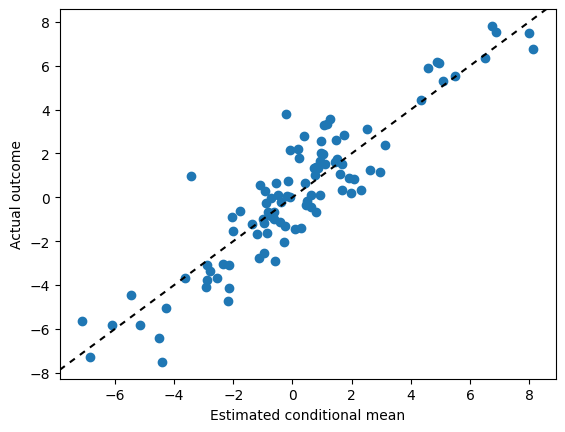

Now, suppose we want to analyze each of the chains separately to assess mixing / convergence.

```python
sigma2_samples = bart_model.global_var_samples
sigma2_samples_by_chain = {"sigma2": np.reshape(sigma2_samples, (num_chains, num_mcmc))}
az.plot_trace(sigma2_samples_by_chain)
```

sigma2_samples = bart_model.global_var_samples sigma2_samples_by_chain = {"sigma2": np.reshape(sigma2_samples, (num_chains, num_mcmc))} az.plot_trace(sigma2_samples_by_chain)

[output not shown]

```python
az.ess(sigma2_samples_by_chain)
```

az.ess(sigma2_samples_by_chain)

```
<xarray.Dataset> Size: 8B
Dimensions:  ()
Data variables:
    sigma2   float64 8B 657.1
```

```python
az.rhat(sigma2_samples_by_chain)
```

az.rhat(sigma2_samples_by_chain)

```
<xarray.Dataset> Size: 8B
Dimensions:  ()
Data variables:
    sigma2   float64 8B 1.014
```

```python
az.plot_autocorr(sigma2_samples_by_chain)
```

az.plot_autocorr(sigma2_samples_by_chain)

[output not shown]

## Sampling Multiple Chains Sequentially from XBART Forests

In the example above, each chain was initialized from "root", meaning each tree in a forest was a single root node and all parameter values were set to a "default" starting point. If we sample a model using a small number of 'grow-from-root' iterations, we can use these forests to initialize MCMC chains.

```python
num_chains = 4
num_gfr = 5
num_burnin = 1000
num_mcmc = 2000
```

num_chains = 4 num_gfr = 5 num_burnin = 1000 num_mcmc = 2000

Run the initial GFR sampler

```python
xbart_model = BARTModel()
xbart_model.sample(
  X_train = X_train,
  leaf_basis_train = leaf_basis_train,
  y_train = y_train,
  num_gfr = num_gfr,
  num_burnin = 0,
  num_mcmc = 0
)
xbart_model_json = xbart_model.to_json()
```

xbart_model = BARTModel() xbart_model.sample( X_train = X_train, leaf_basis_train = leaf_basis_train, y_train = y_train, num_gfr = num_gfr, num_burnin = 0, num_mcmc = 0 ) xbart_model_json = xbart_model.to_json()

Run the multi-chain BART sampler, with each chain initialized from a different GFR forest

```python
bart_model = BARTModel()
bart_model.sample(
  X_train = X_train,
  leaf_basis_train = leaf_basis_train,
  y_train = y_train,
  num_gfr = 0,
  num_burnin = num_burnin,
  num_mcmc = num_mcmc,
  general_params = {'num_chains' : num_chains},
  previous_model_json = xbart_model_json,
  previous_model_warmstart_sample_num = num_gfr - 1
)
```

bart_model = BARTModel() bart_model.sample( X_train = X_train, leaf_basis_train = leaf_basis_train, y_train = y_train, num_gfr = 0, num_burnin = num_burnin, num_mcmc = num_mcmc, general_params = {'num_chains' : num_chains}, previous_model_json = xbart_model_json, previous_model_warmstart_sample_num = num_gfr - 1 )

Now we have a `BARTModel` object with `num_chains * num_mcmc` samples stored internally. These samples are arranged sequentially, with the first `num_mcmc` samples corresponding to chain 1, the next `num_mcmc` samples to chain 2, etc...

Since each chain is a set of samples of the same model, we can analyze the samples collectively, for example, by looking at out-of-sample predictions.

```python
y_hat_test = bart_model.predict(
  X = X_test,
  leaf_basis = leaf_basis_test,
  type = "mean",
  terms = "y_hat"
)
plt.scatter(y_hat_test, y_test)
plt.xlabel("Estimated conditional mean")
plt.ylabel("Actual outcome")
plt.axline((0, 0), slope=1, color="black", linestyle=(0, (3, 3)))
```

y_hat_test = bart_model.predict( X = X_test, leaf_basis = leaf_basis_test, type = "mean", terms = "y_hat" ) plt.scatter(y_hat_test, y_test) plt.xlabel("Estimated conditional mean") plt.ylabel("Actual outcome") plt.axline((0, 0), slope=1, color="black", linestyle=(0, (3, 3)))

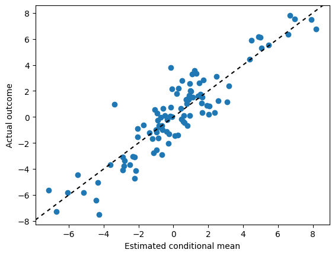

Now, suppose we want to analyze each of the chains separately to assess mixing / convergence.

```python
sigma2_samples = bart_model.global_var_samples
sigma2_samples_by_chain = {"sigma2": np.reshape(sigma2_samples, (num_chains, num_mcmc))}
az.plot_trace(sigma2_samples_by_chain)
```

sigma2_samples = bart_model.global_var_samples sigma2_samples_by_chain = {"sigma2": np.reshape(sigma2_samples, (num_chains, num_mcmc))} az.plot_trace(sigma2_samples_by_chain)

[output not shown]

```python
az.ess(sigma2_samples_by_chain)
```

az.ess(sigma2_samples_by_chain)

```
<xarray.Dataset> Size: 8B
Dimensions:  ()
Data variables:
    sigma2   float64 8B 675.0
```

```python
az.rhat(sigma2_samples_by_chain)
```

az.rhat(sigma2_samples_by_chain)

```
<xarray.Dataset> Size: 8B
Dimensions:  ()
Data variables:
    sigma2   float64 8B 1.003
```

```python
az.plot_autocorr(sigma2_samples_by_chain)
```

az.plot_autocorr(sigma2_samples_by_chain)

[output not shown]

# Demo 2: Causal Inference

## Data Simulation

Simulate a simple partitioned linear model

```python
# Generate the data
n = 1000
p_X = 5
X = rng.uniform(0, 1, (n, p_X))
pi_X = 0.25 + 0.5 * X[:, 0]
Z = rng.binomial(1, pi_X, n).astype(float)
mu_X = pi_X * 5 + 2 * X[:, 2]
tau_X = X[:, 1] * 2 - 1
epsilon = rng.normal(0, 1, n)
E_Y_XZ = mu_X + tau_X * Z
y = E_Y_XZ + epsilon

# Split data into test and train sets
test_set_pct = 0.2
train_inds, test_inds = train_test_split(np.arange(n), test_size=test_set_pct, random_state=random_seed)
n_train = len(train_inds)
n_test = len(test_inds)
X_train = X[train_inds]
X_test = X[test_inds]
Z_train = Z[train_inds]
Z_test = Z[test_inds]
E_Y_XZ_train = E_Y_XZ[train_inds]
E_Y_XZ_test = E_Y_XZ[test_inds]
propensity_train = pi_X[train_inds]
propensity_test = pi_X[test_inds]
y_train = y[train_inds]
y_test = y[test_inds]
```

# Generate the data n = 1000 p_X = 5 X = rng.uniform(0, 1, (n, p_X)) pi_X = 0.25 + 0.5 * X[:, 0] Z = rng.binomial(1, pi_X, n).astype(float) mu_X = pi_X * 5 + 2 * X[:, 2] tau_X = X[:, 1] * 2 - 1 epsilon = rng.normal(0, 1, n) E_Y_XZ = mu_X + tau_X * Z y = E_Y_XZ + epsilon # Split data into test and train sets test_set_pct = 0.2 train_inds, test_inds = train_test_split(np.arange(n), test_size=test_set_pct, random_state=random_seed) n_train = len(train_inds) n_test = len(test_inds) X_train = X[train_inds] X_test = X[test_inds] Z_train = Z[train_inds] Z_test = Z[test_inds] E_Y_XZ_train = E_Y_XZ[train_inds] E_Y_XZ_test = E_Y_XZ[test_inds] propensity_train = pi_X[train_inds] propensity_test = pi_X[test_inds] y_train = y[train_inds] y_test = y[test_inds]

## Sampling Multiple Chains Sequentially from Scratch

The simplest way to sample multiple chains of a stochtree model is to do so "sequentially," that is, after chain 1 is sampled, chain 2 is sampled from a different starting state, and similarly for each of the requested chains. This is supported internally in both the `bart()` and `bcf()` functions, with the `num_chains` parameter in the `general_params` list.

```python
num_chains = 4
num_gfr = 0
num_burnin = 1000
num_mcmc = 2000
```

num_chains = 4 num_gfr = 0 num_burnin = 1000 num_mcmc = 2000

Run the sampler

```python
bcf_model = BCFModel()
bcf_model.sample(
  X_train = X_train,
  Z_train = Z_train,
  propensity_train = propensity_train,
  y_train = y_train,
  num_gfr = num_gfr,
  num_burnin = num_burnin,
  num_mcmc = num_mcmc,
  general_params = {'num_chains' : num_chains}
)
```

bcf_model = BCFModel() bcf_model.sample( X_train = X_train, Z_train = Z_train, propensity_train = propensity_train, y_train = y_train, num_gfr = num_gfr, num_burnin = num_burnin, num_mcmc = num_mcmc, general_params = {'num_chains' : num_chains} )

Since each chain is a set of samples of the same model, we can analyze the samples collectively, for example, by looking at out-of-sample predictions.

```python
y_hat_test = bcf_model.predict(
  X = X_test,
  Z = Z_test,
  propensity = propensity_test,
  type = "mean",
  terms = "y_hat"
)
plt.scatter(y_hat_test, y_test)
plt.xlabel("Estimated conditional mean")
plt.ylabel("Actual outcome")
plt.axline((0, 0), slope=1, color="black", linestyle=(0, (3, 3)))
```

y_hat_test = bcf_model.predict( X = X_test, Z = Z_test, propensity = propensity_test, type = "mean", terms = "y_hat" ) plt.scatter(y_hat_test, y_test) plt.xlabel("Estimated conditional mean") plt.ylabel("Actual outcome") plt.axline((0, 0), slope=1, color="black", linestyle=(0, (3, 3)))

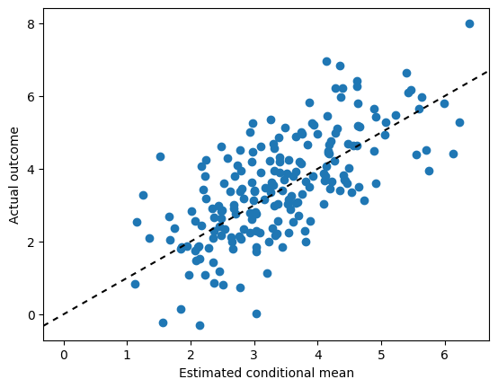

Now, suppose we want to analyze each of the chains separately to assess mixing / convergence.

```python
sigma2_samples = bcf_model.global_var_samples
sigma2_samples_by_chain = {"sigma2": np.reshape(sigma2_samples, (num_chains, num_mcmc))}
az.plot_trace(sigma2_samples_by_chain)
```

sigma2_samples = bcf_model.global_var_samples sigma2_samples_by_chain = {"sigma2": np.reshape(sigma2_samples, (num_chains, num_mcmc))} az.plot_trace(sigma2_samples_by_chain)

[output not shown]

```python
az.ess(sigma2_samples_by_chain)
```

az.ess(sigma2_samples_by_chain)

```
<xarray.Dataset> Size: 8B
Dimensions:  ()
Data variables:
    sigma2   float64 8B 1.988e+03
```

```python
az.rhat(sigma2_samples_by_chain)
```

az.rhat(sigma2_samples_by_chain)

```
<xarray.Dataset> Size: 8B
Dimensions:  ()
Data variables:
    sigma2   float64 8B 1.005
```

```python
az.plot_autocorr(sigma2_samples_by_chain)
```

az.plot_autocorr(sigma2_samples_by_chain)

[output not shown]

## Sampling Multiple Chains Sequentially from XBCF Forests

In the example above, each chain was initialized from "root", meaning each tree in a forest was a single root node and all parameter values were set to a "default" starting point. If we sample a model using a small number of 'grow-from-root' iterations, we can use these forests to initialize MCMC chains.

```python
num_chains = 4
num_gfr = 5
num_burnin = 1000
num_mcmc = 2000
```

num_chains = 4 num_gfr = 5 num_burnin = 1000 num_mcmc = 2000

Run the initial GFR sampler

```python
xbcf_model = BCFModel()
xbcf_model.sample(
  X_train = X_train,
  Z_train = Z_train,
  propensity_train = propensity_train,
  y_train = y_train,
  num_gfr = num_gfr,
  num_burnin = 0,
  num_mcmc = 0
)
xbcf_model_json = xbcf_model.to_json()
```

xbcf_model = BCFModel() xbcf_model.sample( X_train = X_train, Z_train = Z_train, propensity_train = propensity_train, y_train = y_train, num_gfr = num_gfr, num_burnin = 0, num_mcmc = 0 ) xbcf_model_json = xbcf_model.to_json()

Run the multi-chain BCF sampler, with each chain initialized from a different GFR forest

```python
bcf_model = BCFModel()
bcf_model.sample(
  X_train = X_train,
  Z_train = Z_train,
  propensity_train = propensity_train,
  y_train = y_train,
  num_gfr = 0,
  num_burnin = num_burnin,
  num_mcmc = num_mcmc,
  general_params = {'num_chains' : num_chains},
  previous_model_json = xbcf_model_json,
  previous_model_warmstart_sample_num = num_gfr - 1
)
```

bcf_model = BCFModel() bcf_model.sample( X_train = X_train, Z_train = Z_train, propensity_train = propensity_train, y_train = y_train, num_gfr = 0, num_burnin = num_burnin, num_mcmc = num_mcmc, general_params = {'num_chains' : num_chains}, previous_model_json = xbcf_model_json, previous_model_warmstart_sample_num = num_gfr - 1 )

Since each chain is a set of samples of the same model, we can analyze the samples collectively, for example, by looking at out-of-sample predictions.

```python
y_hat_test = bcf_model.predict(
  X = X_test,
  Z = Z_test,
  propensity = propensity_test,
  type = "mean",
  terms = "y_hat"
)
plt.scatter(y_hat_test, y_test)
plt.xlabel("Estimated conditional mean")
plt.ylabel("Actual outcome")
plt.axline((0, 0), slope=1, color="black", linestyle=(0, (3, 3)))
```

y_hat_test = bcf_model.predict( X = X_test, Z = Z_test, propensity = propensity_test, type = "mean", terms = "y_hat" ) plt.scatter(y_hat_test, y_test) plt.xlabel("Estimated conditional mean") plt.ylabel("Actual outcome") plt.axline((0, 0), slope=1, color="black", linestyle=(0, (3, 3)))

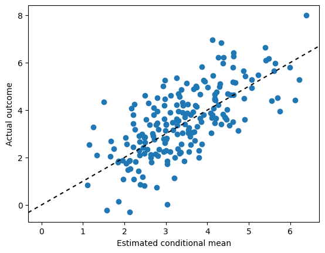

Now, suppose we want to analyze each of the chains separately to assess mixing / convergence.

```python
sigma2_samples = bcf_model.global_var_samples
sigma2_samples_by_chain = {"sigma2": np.reshape(sigma2_samples, (num_chains, num_mcmc))}
az.plot_trace(sigma2_samples_by_chain)
```

sigma2_samples = bcf_model.global_var_samples sigma2_samples_by_chain = {"sigma2": np.reshape(sigma2_samples, (num_chains, num_mcmc))} az.plot_trace(sigma2_samples_by_chain)

[output not shown]

```python
az.ess(sigma2_samples_by_chain)
```

az.ess(sigma2_samples_by_chain)

```
<xarray.Dataset> Size: 8B
Dimensions:  ()
Data variables:
    sigma2   float64 8B 2.602e+03
```

```python
az.rhat(sigma2_samples_by_chain)
```

az.rhat(sigma2_samples_by_chain)

```
<xarray.Dataset> Size: 8B
Dimensions:  ()
Data variables:
    sigma2   float64 8B 1.003
```

```python
az.plot_autocorr(sigma2_samples_by_chain)
```

az.plot_autocorr(sigma2_samples_by_chain)

[output not shown]